# Practical Machine Learning Project

Niamh Phillips

19/06/2020

## Assignment

One thing that people regularly do is quantify how much of a particular activity they do, but they rarely quantify how well they do it. In this project, your goal will be to use data from accelerometers on the belt, forearm, arm, and dumbell of 6 participants.

The goal of your project is to predict the manner in which they did the exercise. This is the “classe” variable in the training set. You may use any of the other variables to predict with. You should create a report describing how you built your model, how you used cross validation, what you think the expected out of sample error is, and why you made the choices you did. You will also use your prediction model to predict 20 different test cases.

### Background Information

Using devices such as Jawbone Up, Nike FuelBand, and Fitbit it is now possible to collect a large amount of data about personal activity relatively inexpensively. These type of devices are part of the quantified self movement – a group of enthusiasts who take measurements about themselves regularly to improve their health, to find patterns in their behavior, or because they are tech geeks. One thing that people regularly do is quantify how much of a particular activity they do, but they rarely quantify how well they do it. In this project, your goal will be to use data from accelerometers on the belt, forearm, arm, and dumbell of 6 participants. They were asked to perform barbell lifts correctly and incorrectly in 5 different ways. More information is available from the website here: http://web.archive.org/web/20161224072740/http:/groupware.les.inf.puc-rio.br/har (see the section on the Weight Lifting Exercise Dataset).

### Data

The training data for this project are available here:

https://d396qusza40orc.cloudfront.net/predmachlearn/pml-training.csv

The test data are available here:

https://d396qusza40orc.cloudfront.net/predmachlearn/pml-testing.csv

The data for this project come from this source: http://web.archive.org/web/20161224072740/http:/groupware.les.inf.puc-rio.br/har. If you use the document you create for this class for any purpose please cite them as they have been very generous in allowing their data to be used for this kind of assignment.

## Leading and Preparing Data

```r
library(caret)
##install.packages("corrplot")
##install.packages("rpart")
##install.packages("rpart.plot")
##install.packages("rpart.plot")
##install.packages("rattle")
library(rattle)
library(rpart)
library(rpart.plot)
library(corrplot)
train <- read.csv("pml-training.csv")
test <- read.csv("pml-testing.csv")

dim(train)
```

```
## [1] 19622   160
```

```r
dim(test)
```

```
## [1]  20 160
```

```r
sum(complete.cases(train))
```

```
## [1] 406
```

. The training data set contains 19622 observations and 160 variables . The testing data set contains 20 observations and 160 variables

Next we need to split the training data into two and create a seed to make it reproducable. As well as removing NA and near zero values

```r
set.seed(10)
inTrain  <- createDataPartition(train$classe, p=0.7, list=FALSE)
TrainSet <- train[inTrain, ]
TestSet  <- train[-inTrain, ]
dim(TrainSet)
```

```
## [1] 13737   160
```

```r
dim(TestSet)
```

```
## [1] 5885  160
```

```r
NZV <- nearZeroVar(TrainSet)
TrainSet <- TrainSet[, -NZV]
TestSet  <- TestSet[, -NZV]
dim(TrainSet)
```

```
## [1] 13737   108
```

```r
dim(TestSet)
```

```
## [1] 5885  108
```

```r
# remove identification only variables (columns 1 to 5)
TrainSet <- TrainSet[, -(1:5)]
TestSet  <- TestSet[, -(1:5)]
dim(TrainSet)
```

```
## [1] 13737   103
```

```r
AllNA    <- sapply(TrainSet, function(x) mean(is.na(x))) > 0.95
TrainSet <- TrainSet[, AllNA==FALSE]
TestSet  <- TestSet[, AllNA==FALSE]
```

## Model Building

Correlation amoungst vriables is shown below

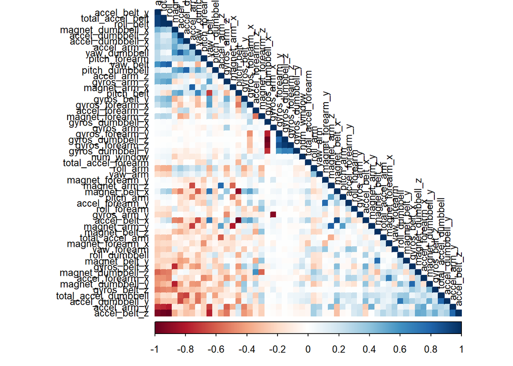

```r
corMatrix <- cor(TrainSet[, -54])
corrplot(corMatrix, order = "FPC", method = "color", type = "lower",
         tl.cex = 0.8, tl.col = rgb(0, 0, 0))
```

The highly correlated variables are shown in dark colors in the graph above

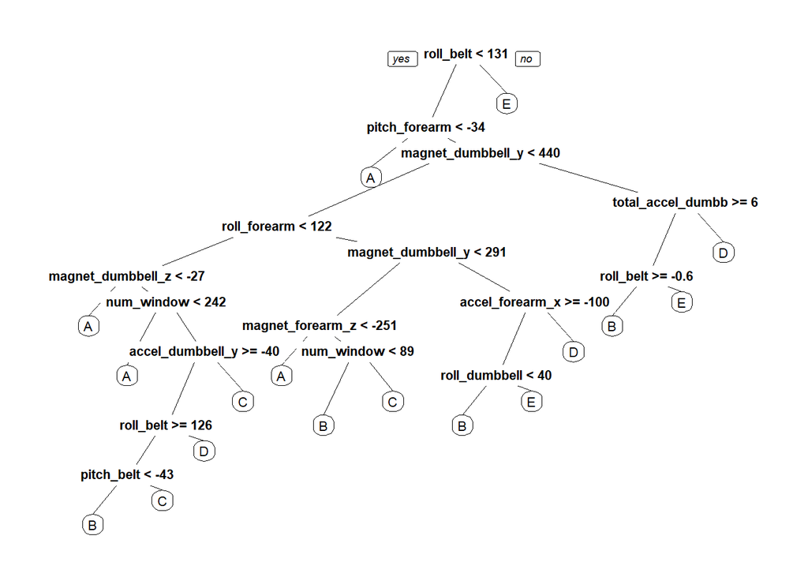

```r
# model fit
set.seed(1221)
treeModel <- rpart(classe ~ ., data=TrainSet, method="class")
prp(treeModel) # fast plot
```

[figure not shown]

```r
set.seed(12345)
library(rpart)
decisionTreeMod1 <- rpart(classe ~ ., data=TrainSet, method="class")
fancyRpartPlot(decisionTreeMod1)
```

```r
predictTreeMod1 <- predict(decisionTreeMod1, TestSet, type = "class")
cmtree <- confusionMatrix(predictTreeMod1, TestSet$classe)
cmtree
```

```
## Confusion Matrix and Statistics
##
##           Reference
## Prediction    A    B    C    D    E
##          A 1443  184   10   82   73
##          B   44  570   32   16   93
##          C   19   77  775  143   97
##          D  141  238  136  660  121
##          E   27   70   73   63  698
##
## Overall Statistics
##
##                Accuracy : 0.7045
##                  95% CI : (0.6927, 0.7161)
##     No Information Rate : 0.2845
##     P-Value [Acc > NIR] : < 2.2e-16
##
##                   Kappa : 0.6262
##
##  Mcnemar's Test P-Value : < 2.2e-16
##
## Statistics by Class:
##
##                      Class: A Class: B Class: C Class: D Class: E
## Sensitivity            0.8620  0.50044   0.7554   0.6846   0.6451
## Specificity            0.9171  0.96102   0.9308   0.8708   0.9515
## Pos Pred Value         0.8052  0.75497   0.6976   0.5093   0.7497
## Neg Pred Value         0.9436  0.88908   0.9474   0.9338   0.9225
## Prevalence             0.2845  0.19354   0.1743   0.1638   0.1839
## Detection Rate         0.2452  0.09686   0.1317   0.1121   0.1186
## Detection Prevalence   0.3045  0.12829   0.1888   0.2202   0.1582
## Balanced Accuracy      0.8896  0.73073   0.8431   0.7777   0.7983
```

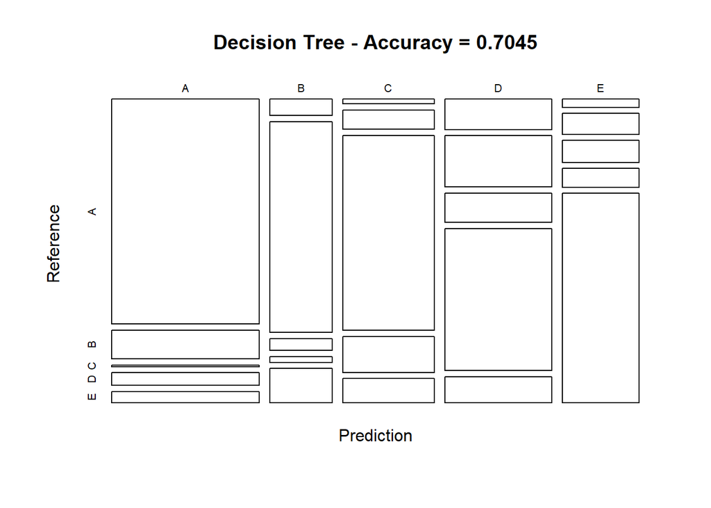

```r
plot(cmtree$table, col = cmtree$byClass,
     main = paste("Decision Tree - Accuracy =", round(cmtree$overall['Accuracy'], 4)))
```